# Research: IDEA Climate Survey 2022-2023

research design

analysis

dataviz

Published

July 21, 2023

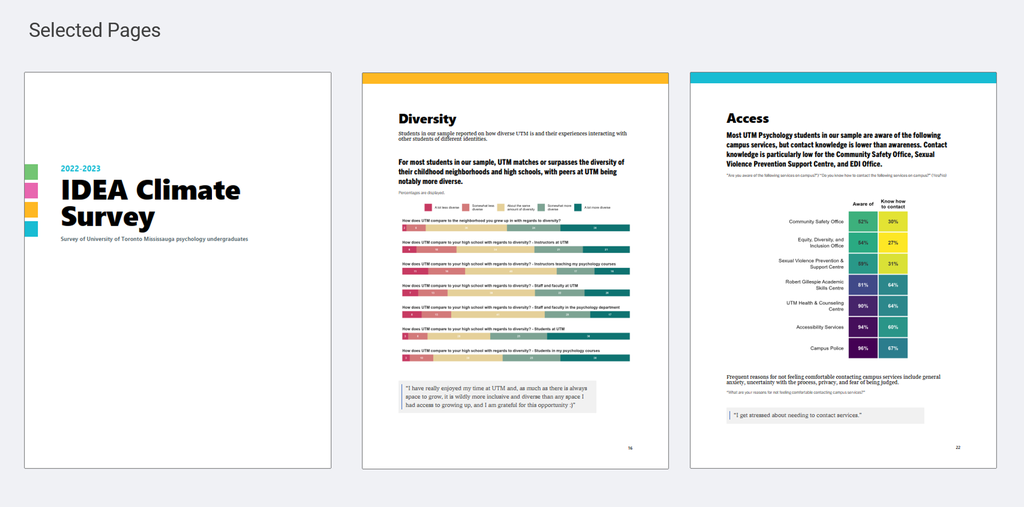

## Objective

To evaluate the climate of inclusion, diversity, equity, and access (IDEA) among undergraduate psychology students at the University of Toronto Mississauga. The survey aimed to identify key areas of strength and improvement by gathering insights into students’ experiences and perceptions regarding these dimensions.

## Approach

The project involved the design and execution of a detailed survey distributed over several months. As a key project administrator and methodologist, I coordinated the efforts of faculty, postdocs, graduate, and undergraduate students, ensuring rigorous data analysis and results presentation. We crafted the survey to capture a wide range of demographic information and students’ personal experiences with IDEA-related issues. Analysis involved quantitative and qualitative methods to thoroughly examine the data collected.

## Tools Used

The survey was developed and analyzed using a combination of statistical software (R, SPSS, Excel) and qualitative analysis tools. Data curation, formal analysis, and visualization were performed using advanced statistical software packages. Contributions included data analysis, writing, and clear visualization of findings for report preparation.

Read the report